# Research Report

### ----- Zicheng Zhao -----

- Problem Identification
- Literature Review
- Feature Engineering & EDA
- Preliminary Finding
- Methodology
  - CNN Practice
  - GNN Exploration
- Next Step

### 1. Problem Identification

### Title:

**Hybrid CNN-GNN Model for Multiple Ocular Disease Classification**

### Proposal:

Early detection of **retinal diseases**, such as diabetic retinopathy, glaucoma, and age-related macular degeneration (AMD), is essential to prevent vision loss. **Traditional Convolutional Neural Networks (CNNs)** have achieved promising results in analyzing retinal images by **extracting local spatial features** but often fail to **capture complex interdependencies** between distinct regions of the retina.

We propose a hybrid model that **combines CNNs with Graph Neural Networks (GNNs)** to enhance multi-disease classification by **leveraging both spatial and relational information** from retinal images. CNNs are employed to extract high-level feature representations from retinal regions of interest (ROIs), while GNNs model the relationships between these regions, effectively capturing disease co-occurrence and interdependencies.

We anticipate that this combined approach will lead to **improved accuracy in multi-disease classification** and offer interpretability through attention mechanisms, illuminating which retinal regions contribute most significantly to the model's predictions.

This work aims to advance computer-aided diagnosis in ophthalmology by demonstrating a polished novel, relational approach to multi-disease classification from fundus images.

### 2. Literature Review

1. Li, N., Li, T., Hu, C., Wang, K., & Kang, H. (2021). **A Benchmark of Ocular Disease Intelligent Recognition: One Shot for Multi-disease Detection.**
- This paper used the ODIR dataset with multi-disease detection in fundus images provided, which from both eyes of 5000 patients with annotations for 8 different disease including diabetic retinopathy, glaucoma, cataract, age-related macular degeneration, and others. We will also use this dataset.
- The paper performed experiments on several deep learning models for multi-disease classification and found that simply increasing the scale of the network isn’t enough, and a specialized feature fusion approach is expected.
- The paper suggests that using a graph neural network could be a potential application of the dataset: “multi-model data makes it possible to develop more accurate disease identification models. For example, graph neural network can be used to integrate un-structured data to further improve diagnostic accuracy.” The diverse and multi-label nature makes it well-suited for exploring GNN.
- The scale of dataset has limitation and would be great if is more amplified, problems include more images for generalizations, distribution’s imbalance, etc.
2. Pachade, S., Porwal, P., Thulkar, D., Kokare, M., Deshmukh, G., Sahasrabuddhe, V., Giancardo, L., Quellec, G., & Mériaudeau, F. (2021). **Retinal Fundus Multi-Disease Image Dataset (RFMiD): A Dataset for Multi-Disease Detection Research.**
- This paper provides a new publicly available dataset consisting of 3200 retinal fundus images with annotations for 46 different eye conditions.
- The dataset can be used to combine with the previous paper’s datasets for data scale enlargement.
3. Huang, F., Lian, J., Ng, K.-S., Shih, K., & Vardhanabhuti, V. (2022). **Predicting CT-Based Coronary Artery Disease Using Vascular Biomarkers Derived from Fundus Photographs with a Graph Convolutional Neural Network.** Diagnostics, 12(6), 1390.
- This paper used graph neural network model to predict the CAD-RADS (Coronary Artery Disease Reporting and Data System) score using quantitative vascular biomarkers such as arterial width and angle, venous angle, and fractal dimensions derived from fundus photographs, which are found significantly associated with the score.
- The paper specifically used the GraphSAGE network to predict CAD-RADS score, with the key steps including:
  - Construct a population graph where the nodes represent the fundus image samples, and the edges were defined based on the similarity in age and gender between the subjects.
  - The nodes were characterized by 96 quantitative retinal vascular biomarkers extracted from the fundus images.
  - They then trained the GraphSAGE network on this graph to predict the CAD-RADS score, which was used as a proxy for coronary artery disease. The results showed that the GNN model outperformed traditional ML models. This research demonstrates the potential of using GNN models on fundus images for disease diagnosis. The graph-based approach allows the model to capture the complex relationship between the retinal vascular biomarkers and the underlying CAD, which traditional ML models may struggle to capture.
- The GraphSAGE model doesn’t include a CNN component, and the biomarker extraction doesn’t use CNN either, instead, used traditional image processing. FYI, GraphSAGE is a graph neural network that learns aggregation functions to generate low-dimension vectors from the high-dimensional node features and the complicated node connectivity in the graph.
4. D. Nagasudha, A. Akash, B. Vanessa Thanmayi, CH. Vaishnavi, B. Raghavi, and R. Pitchai, **"An Approach for Diabetic Retinopathy using GNN,"** in 2023 6th International Conference on Contemporary Computing and Informatics (IC3I), 2023, pp. 2408-2414, doi: 10.1109/IC3I59117.2023.10398143.
- The paper presents an approach for detecting diabetic retinopathy using Graph Neural Networks (GNNs). The key idea is to represent the retinal image as a graph, where pixels serve as nodes and their connections as edges. GNNs then can be used to learn the characteristics of this graph representation and detect.
  - Firstly, connect a large dataset of retinal images labeled as normal or having diabetic retinopathy.
  - The retinal images were then transformed into graph representations, where each pixel served as a node in the graph, and the edges represented the relationships between the pixels. Different methods were used to construct these graphs, such as using a fully connected graph, a k-nearest neighbours’ graph, or a graph based on the retinal vasculature.
  - Then the GNN is employed to learn the characteristics of the nodes and edges in the graph, which involved the process of passing messages between nodes and updating their feature representations based on information from their neighboring nodes.
  - Popular GNN architectures including GCN, GAT, or GraphSAGE, were used for the feature extraction process.
- The paper highlights the outperformance of GNN over CNN in capturing complex relationships between image features.
- The paper discusses the objectives of using GNNs for diabetic retinopathy detection, such as automating the examination process and assessing the effectiveness of GNN algorithms on diverse retinal image datasets.
5. Rodrigues, J. and Carbonera, J. (2024). **Graph Convolutional Networks for Image Classification: Comparing Approaches for Building Graphs from Images.** In Proceedings of the 26th International Conference on Enterprise Information Systems (ICEIS 2024) - Volume 1, pages 437-446.
- The paper focuses on the use of graph convolutional networks (GCNs) for image classification tasks, where images are represented as graphs. The impact of different approaches for representing image as graphs on the performance of a GCN model is systematically evaluated.
- Specifically, it analyzed the degree of image segmentation, the set of features used to represent each super-pixel as a node, and the method for building the edges between nodes.
- The performance of the GCN model is positively impacted by choosing rich representative features sets, increasing super-pixels per image’s number, and building neighbourhoods between nodes that encompass only similar regions.
6. Zhou, X.; Zhang, Y.; Wei, Q. **Few-Shot Fine-Grained Image Classiﬁcation via GNN.** Sensors 2022, 22, 7640.
- The paper proposes a GNN-based framework for few-shot fine-grained image classification. Traditional deep learning methods require many labeled samples, which can be costly to obtain for fine-grained image data.
- The framework uses GNN to better capture the subtle differences between fine-grained image classes by modelling the in-class similarity and inter-class differences.
- The paper optimizes the feature extraction model using meta-learning to improve the overall classification performance and prevent the network from getting stuck in local optima.
7. Chen, Z.-M., Wei, X.-S., Wang, P., & Guo, Y. (2019). **Multi-Label Image Recognition with Graph Convolutional Networks.**
- The paper proposes a novel multi-label image framework based on GCNs. The key idea is to model the dependencies between object labels using a directed graph, where each node represents a label, and the edges capture the co-occurrence patterns between labels. The GCN is then used to map the label representations into a set of inter-dependent object classifiers, which are then applied to the image features for multi-label prediction.
- Image representation learning module: It used a CNN base model (ResNet-101) to learn the features of an input image and obtain the image-level feature vector.
- GCN-based classifier learning module: It designed the final output of each GCN node to be the classifier of the corresponding label, and constructed the correlation matrix from scratch since it was not provided in the multi-label image recognition task.
- The paper proposes an effective re-weighted scheme to construct the label correlation matrix, which guides the information propagation in the GCN and helps alleviate overfitting and over-smoothing issues.
8. Yao, R. et al. (2025). **GKGNet: Group K-Nearest Neighbor Based Graph Convolutional Network for Multi-label Image Recognition.** In: Leonardis, A., Ricci, E., Roth, S., Russakovsky, O., Sattler, T., Varol, G. (eds) Computer Vision – ECCV 2024. ECCV 2024. Lecture Notes in Computer Science, vol 15076. Springer, Cham. https://doi.org/10.1007/978-3-031-72649-1_6
- The paper introduces GKGNet, the first fully graph convolutional model for multi-label image recognition. It builds unified graph representations for visual features and label embeddings, explicitly modeling the flexible relationship between labels and regions of interest.
- To handle scale variance and capture diverse perspectives, the authors propose the Group KGCN module for dynamic graph construction and message passing.
  - It constructs a unified graph representation that models the relationship between visual features and label embeddings.
  - The patch-level group KGCN model enables dynamic graph construction and message passing to handle scale variance and capture diverse perspectives.
  - The cross-level graph module models the intricate object-object and label-object relations across different scales.
  - The Group KNN technique is used to enhance the general classification performance of the underlying visual feature extractor.
9. Cheng, Y., Ma, M., Li, X., & Zhou, Y. (2021). **Multi-label classification of fundus images based on graph convolutional network.** BMC Medical Informatics and Decision Making, 21(Suppl 2), 82.
- The paper presents a multi-label classification method based on GCN to detect multiple lesions in color fundus images.
- They constructed a specialized corpus of fundus lesions and used a multi-label classification algorithm based on the GCN to train the model.
10. Beghdadi, A., Beghdadi, A., Ullah, M., Cheikh, F. A., & Mallem, M. (2023). **A New Lightweight Hybrid Graph Convolutional Neural Network - CNN Scheme for Scene Classification using Object Detection Inference.**
- The paper proposes a new lightweight hybrid graph convolutional neural network for scene classification using object detection inference.
- The proposed approach uses the output of a CNN object detection model to predict the observed scene type by generating a coherent GCNN representing the semantic and geometric content of the observed scene.
- It incorporates the semantic contents and spatial distribution of objects for better extraction of scene features and visual information context.
11. Jiao, Z., Zhang, H., & Li, X. (2022). **CNN2GNN: How to Bridge CNN with GNN.**
- This paper can be used for future direction, since a hybrid model may make the research performing better.

### 3. Feature Engineering & EDA

For the scale of our dataset, we collected data from **different sources**. We then need to wrangle, clean, and merge them into an ideal structure and format based on their respective information.

Firstly, we introduce the 2 different sources (*All From Kaggle*):

1. ODIR-5K dataset (Ocular Disease Recognition)
2. RFMiD dataset (Retinal Disease Classification)

For these two data source, we will use them in a way of:

- First dataset for training and validation
- Second dataset for pure testing

This brings us a **more confident model's result**, since it will let us having *more data to train the model, and more data (a total separated source) to test the model*.

```python
import kagglehub

# Download ODIR-5K dataset (Ocular Disease Recognition)
odir_path = kagglehub.dataset_download("andrewmvd/ocular-disease-recognition-odir5k")
print("Path to ODIR dataset files:", odir_path)
```

```
Downloading from https://www.kaggle.com/api/v1/datasets/download/andrewmvd/ocular-disease-recognition-odir5k?dataset_version_number=2...
```

```
Extracting files...
```

```
Path to ODIR dataset files: /root/.cache/kagglehub/datasets/andrewmvd/ocular-disease-recognition-odir5k/versions/2
```

Now we will inspect each data sources respectively and start tidying them up for the upcoming merging and combining.

Here is the general information about these data sources:

1. ODIR:

   The dataset has a structured ophthalmic database of 5,000 patients (**with around 4000 of them labelled**) with age, color fundus photographs from left and right eyes and doctors' diagnostic keywords from doctors among *8 categories*.

   The dataset has a structured ophthalmic database with multiple diseases' classification being given, with some of them *uncommon to see* or *lacking adequate data for training*. Therefore, we will look through other sources' situation and **filter out certain types of diseases** by *merging them into a general category of abnormility* possibly.

Firstly, we'll deal with **ODIR** dataset:

```python
import pandas as pd

# Load ODIR dataset
odir_metadata = pd.read_csv(f"{odir_path}/full_df.csv")

# Display the first few rows of the dataset and its columns to understand the structure
odir_metadata.head(), odir_metadata.columns
```

```
(   ID  Patient Age Patient Sex Left-Fundus Right-Fundus  \
 0   0           69      Female  0_left.jpg  0_right.jpg
 1   1           57        Male  1_left.jpg  1_right.jpg
 2   2           42        Male  2_left.jpg  2_right.jpg
 3   4           53        Male  4_left.jpg  4_right.jpg
 4   5           50      Female  5_left.jpg  5_right.jpg

                             Left-Diagnostic Keywords  \
 0                                           cataract
 1                                      normal fundus
 2  laser spot，moderate non proliferative retinopathy
 3                        macular epiretinal membrane
 4             moderate non proliferative retinopathy

                 Right-Diagnostic Keywords  N  D  G  C  A  H  M  O  \
 0                           normal fundus  0  0  0  1  0  0  0  0
 1                           normal fundus  1  0  0  0  0  0  0  0
 2  moderate non proliferative retinopathy  0  1  0  0  0  0  0  1
 3       mild nonproliferative retinopathy  0  1  0  0  0  0  0  1
 4  moderate non proliferative retinopathy  0  1  0  0  0  0  0  0

                                             filepath labels  \
 0  ../input/ocular-disease-recognition-odir5k/ODI...  ['N']
 1  ../input/ocular-disease-recognition-odir5k/ODI...  ['N']
 2  ../input/ocular-disease-recognition-odir5k/ODI...  ['D']
 3  ../input/ocular-disease-recognition-odir5k/ODI...  ['D']
 4  ../input/ocular-disease-recognition-odir5k/ODI...  ['D']

                      target     filename
 0  [1, 0, 0, 0, 0, 0, 0, 0]  0_right.jpg
 1  [1, 0, 0, 0, 0, 0, 0, 0]  1_right.jpg
 2  [0, 1, 0, 0, 0, 0, 0, 0]  2_right.jpg
 3  [0, 1, 0, 0, 0, 0, 0, 0]  4_right.jpg
 4  [0, 1, 0, 0, 0, 0, 0, 0]  5_right.jpg  ,
 Index(['ID', 'Patient Age', 'Patient Sex', 'Left-Fundus', 'Right-Fundus',
        'Left-Diagnostic Keywords', 'Right-Diagnostic Keywords', 'N', 'D', 'G',
        'C', 'A', 'H', 'M', 'O', 'filepath', 'labels', 'target', 'filename'],
       dtype='object'))
```

Since here we temporarily don't consider using the patients' information, we will simplify the dataset's structure, so it'll be **an image / unit** instead of **a patient / unit**.

```python
# Keep only necessary columns for each image as a unit
odir_df = odir_metadata[['filename','labels']]

odir_df.head()
```

|  | filename | labels |
| --- | --- | --- |
| 0 | 0_right.jpg | ['N'] |
| 1 | 1_right.jpg | ['N'] |
| 2 | 2_right.jpg | ['D'] |
| 3 | 4_right.jpg | ['D'] |
| 4 | 5_right.jpg | ['D'] |

Now, we will use **One-Hot Encoding** to represent each conditions in individual columns and show their presence with 0 and 1.

```python
# Make a copy to avoid any SettingWithCopyWarning
odir_df = odir_df.copy()

# List of possible labels
conditions = ['N', 'D', 'G', 'C', 'A', 'H', 'M', 'O']

# Create columns for each label, set to 1 if label is in the list for that row, else 0
for condition in conditions:
    odir_df.loc[:, condition] = odir_df['labels'].apply(lambda x: 1 if condition in x else 0)

# Drop the original 'labels' column
odir_df = odir_df.drop(columns=['labels'])

# Display the transformed DataFrame
odir_df.head()
```

|  | filename | N | D | G | C | A | H | M | O |
| --- | --- | --- | --- | --- | --- | --- | --- | --- | --- |
| 0 | 0_right.jpg | 1 | 0 | 0 | 0 | 0 | 0 | 0 | 0 |
| 1 | 1_right.jpg | 1 | 0 | 0 | 0 | 0 | 0 | 0 | 0 |
| 2 | 2_right.jpg | 0 | 1 | 0 | 0 | 0 | 0 | 0 | 0 |
| 3 | 4_right.jpg | 0 | 1 | 0 | 0 | 0 | 0 | 0 | 0 |
| 4 | 5_right.jpg | 0 | 1 | 0 | 0 | 0 | 0 | 0 | 0 |

Just for revising, for the labels here, each represents: **normal (N),diabetes (D), glaucoma (G), cataract (C), AMD (A), hypertension (H), myopia (M), other diseases/abnormalities (O)**

For the feature engineering of the other dataset, we plan to use **ODIR** dataset as a **full train-validation set**, and the other one, **RFMiD** as a **full test set**.

Therefore, we are not in a rush of dealing with **RFMiD** feature engineering at this stage, since we can process it once we started running another round of try-out based on the ideaology of the data practice above.

### 4. Preliminary Finding

From the paper that's related to the **ODIR** dataset, we could obtain some findings as below:

- The paper indicates that the proposed model should focus on effectively **fusing features from multiple diseases** to improve classification accuracy.
- The authors suggest potential applications of the dataset, such as developing image captioning algorithms and integrating unstructured data **using graph neural networks** to further improve diagnostic accuracy.

From the paper that proposed an approach for diabetic retinopathy using GNN, we could obtain some findings as below:

- The fundus images used in this research are pre-processed by resizing them to a **common size of 224 x 224 pixels**.
- The severity of the diabetic retinopathy cases in the dataset ranges from "no pdr" to "severe" (0 to 3), which also refers as a **classification problem**, is tackled by GCN models from this paper.

More preliminary finds are covered in the **literature review**.

Generally, we know about the **CNN's power of spatial data processing**, and **GNN's power of relational data processing**. Therefore, a combination of two is technically an ideal approach of image analysis for disease diagnosis.

### 5. Methodology Practice

Since we are aiming to figure out a *hybrid CNN-GNN model* for fundus image analysis, we would like to firstly **replicate the procedures on CNN foundations only**.

Before doing that, we will try to manually build up a CNN model to showcase our understanding to fundus image analysis.

By aligning with the coursework's CNN model construction's procedures, we will mock the process and build up a specific model for **ODIR** dataset.

```python
# import libraries
import os
import pandas as pd
import numpy as np
import torch
import torch.nn as nn
import torch.nn.functional as F
from torchsummary import summary
from torchvision import transforms, datasets
from sklearn.model_selection import train_test_split
from torch.utils.data import DataLoader, TensorDataset, Dataset, random_split
from PIL import Image
import matplotlib.pyplot as plt
```

##### Import and Process the data

```python
img_path = f"{odir_path}/preprocessed_images"
```

```python
# Define a custom dataset
class ODIRDataset(Dataset):
    # Firstly, we initialize parameters:
    # dataframe, image folder direction, and transformation
    def __init__(self, dataframe, img_dir, transform=None):
        self.dataframe = dataframe
        self.img_dir = img_dir
        self.transform = transform

    # Secondly, we return the total number of rows in dataframe
    # It tells PyTorch how many samples exist
    def __len__(self):
        return len(self.dataframe)

    # idx refers to the index of the row corresponding the the sample we want
    # open the image using Pillow and convert it to RGB format
    # Retrieve all the rows and convert it to a NumPy array
    # and transform it into PyTorch tensor of type float 32 (One-Hot encode)
    # if a transformation is provided, apply it to the image
    # In the end, returns the transformed image and its label
    def __getitem__(self, idx):
      img_name = os.path.join(self.img_dir, self.dataframe.iloc[idx, 0])
      image = Image.open(img_name).convert("RGB")

      # Ensure labels are converted to a list before creating a tensor
      labels = torch.tensor(self.dataframe.iloc[idx, 1:].astype(float).tolist(),
                            dtype=torch.float32)

      if self.transform:
          image = self.transform(image)

      return image, labels

# Data transforms
transform = transforms.Compose([
    transforms.Resize((224, 224)),
    transforms.ToTensor()
])

# Create dataset
dataset = ODIRDataset(odir_df, img_path, transform)
```

##### Create train/test groups using DataLoader

```python
# Split dataset into train/test
# Split the DataFrame
train_df, test_df = train_test_split(odir_df, test_size=0.2, random_state=42)

# Create Dataset objects for train and test
train_dataset = ODIRDataset(train_df,
                            img_dir=f"{odir_path}/preprocessed_images",
                            transform=transform)
test_dataset = ODIRDataset(test_df,
                           img_dir=f"{odir_path}/preprocessed_images",
                           transform=transform)

# Create DataLoaders
train_loader = DataLoader(train_dataset, batch_size=32, shuffle=True)
test_loader = DataLoader(test_dataset, batch_size=len(test_dataset),
                         shuffle=False)
```

##### Create the DL model

```python
def createODIRNet(printtoggle=False):
    # Define the model class
    class ODIRNet(nn.Module):
        def __init__(self, printtoggle):
            super().__init__()

            ### Convolutional layers
            self.conv1 = nn.Conv2d(3, 16, kernel_size=3, stride=1, padding=1)
            self.conv2 = nn.Conv2d(16, 32, kernel_size=3, stride=1, padding=1)
            self.conv3 = nn.Conv2d(32, 64, kernel_size=3, stride=1, padding=1)
            self.conv4 = nn.Conv2d(64, 128, kernel_size=3, stride=1, padding=1)

            ### Fully connected layers
            # No GAP, so we compute flattened size manually
            self.fc1 = nn.Linear(128 * 14 * 14, 256)  # Assuming input: 224x224
            self.fc2 = nn.Linear(256, 128)
            self.out = nn.Linear(128, 8)  # Output for 8 classes (multi-label)

            # Dropout layers for regularization
            self.drop1 = nn.Dropout(0.3)  # Dropout after first FC layer
            self.drop2 = nn.Dropout(0.3)  # Dropout after second FC layer

            # Toggle for printing tensor shapes
            self.print = printtoggle

        # Forward pass
        def forward(self, x):

            # Convolutional layers with ReLU
            x = F.relu(F.max_pool2d(self.conv1(x), 2))

            x = F.relu(F.max_pool2d(self.conv2(x), 2))

            x = F.relu(F.max_pool2d(self.conv3(x), 2))

            x = F.relu(F.max_pool2d(self.conv4(x), 2))

            # Flatten the tensor for the fully connected layers
            nUnits = x.shape.numel() // x.shape[0]  # Total units per sample
            x = x.view(-1, nUnits)

            # Fully connected layers
            x = F.relu(self.fc1(x))
            x = self.drop1(x)  # Dropout after first FC layer

            x = F.relu(self.fc2(x))
            x = self.drop2(x)  # Dropout after second FC layer

            x = torch.sigmoid(self.out(x))  # Output layer

            return x

    # Create the model instance
    net = ODIRNet(printtoggle)

    # Loss function (Binary Cross Entropy for multi-label classification)
    lossfun = nn.BCELoss()

    # Optimizer
    optimizer = torch.optim.Adam(net.parameters(), lr=0.001)

    return net, lossfun, optimizer
```

```python
# test the model with one batch
net,lossfun,optimizer = createODIRNet(True)

X,y = next(iter(train_loader))
yHat = net(X)
y = torch.squeeze(y)
# check sizes of model outputs and target variable
print(' ')
print(yHat.shape)
print(y.shape)

# now let's compute the loss
loss = lossfun(yHat,y)
print(' ')
print('Loss:')
print(loss)
```

```
torch.Size([32, 8])
torch.Size([32, 8])

Loss:
tensor(0.6938, grad_fn=<BinaryCrossEntropyBackward0>)
```

```python
device = torch.device("cuda" if torch.cuda.is_available() else "cpu")
net = net.to(device)

summary(net,(3,224,224))
```

```
----------------------------------------------------------------
        Layer (type)               Output Shape         Param #
================================================================
            Conv2d-1         [-1, 16, 224, 224]             448
            Conv2d-2         [-1, 32, 112, 112]           4,640
            Conv2d-3           [-1, 64, 56, 56]          18,496
            Conv2d-4          [-1, 128, 28, 28]          73,856
            Linear-5                  [-1, 256]       6,422,784
           Dropout-6                  [-1, 256]               0
            Linear-7                  [-1, 128]          32,896
           Dropout-8                  [-1, 128]               0
            Linear-9                    [-1, 8]           1,032
================================================================
Total params: 6,554,152
Trainable params: 6,554,152
Non-trainable params: 0
----------------------------------------------------------------
Input size (MB): 0.57
Forward/backward pass size (MB): 11.49
Params size (MB): 25.00
Estimated Total Size (MB): 37.07
----------------------------------------------------------------
```

##### Create a function that trains the model

We use `tqdm` to show the progress of the model training.

```python
from tqdm import tqdm

def trainODIRModel(num_epochs=10):
    # Initialize the model, loss function, and optimizer
    net, lossfun, optimizer = createODIRNet(True)

    # Initialize storage for loss and accuracy
    losses = torch.zeros(num_epochs)
    trainAcc = []
    testAcc = []

    # Check for GPU availability
    device = torch.device('cuda' if torch.cuda.is_available() else 'cpu')
    net.to(device)

    # Epoch-level progress bar
    for epochi in tqdm(range(num_epochs), desc="Training Progress"):
        # Set model to training mode
        net.train()
        batchAcc = []
        batchLoss = []

        # Loop over training batches
        for X, y in train_loader:
            X, y = X.to(device), torch.squeeze(y.to(device))  # Move data to device

            # Forward pass
            yHat = net(X)
            loss = lossfun(yHat, y)

            # Backpropagation
            optimizer.zero_grad()
            loss.backward()
            optimizer.step()

            # Store batch loss
            batchLoss.append(loss.item())

            # Calculate multi-label accuracy
            accuracyPct = 100 * torch.mean(((yHat > 0.5).float() == y).float())
            batchAcc.append(accuracyPct.item())

        # Average training accuracy and loss over batches
        trainAcc.append(np.mean(batchAcc))
        losses[epochi] = np.mean(batchLoss)

        # Test accuracy after each epoch
        net.eval()
        with torch.no_grad():  # Deactivate autograd for testing
            testAccBatch = []
            for X, y in test_loader:
                X, y = X.to(device), torch.squeeze(y.to(device))
                yHat = net(X)
                testAccBatch.append(100 * torch.mean(((yHat > 0.5).float() == y).float()).item())
        testAcc.append(np.mean(testAccBatch))

    # Return training accuracy, test accuracy, losses, and the trained model
    return trainAcc, testAcc, losses, net
```

Here we use `y(Hat > 0.5).float` instead of `torch.argmax(yHat, axis=1)` because one input sample may has multiple labels.

```python
# Train the model with progress bar and epoch summary
trainAcc, testAcc, losses, net = trainODIRModel(num_epochs=10)
```

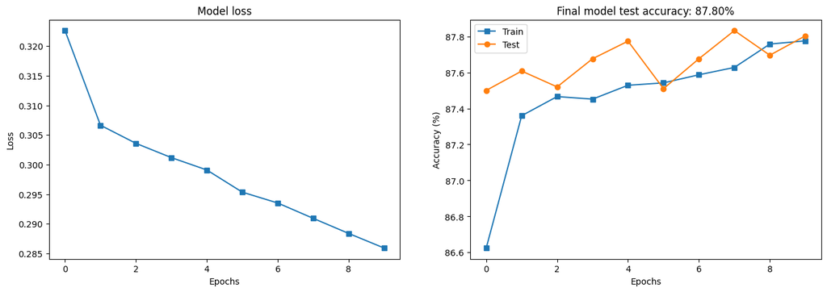

```python
fig,ax = plt.subplots(1,2,figsize=(16,5))

ax[0].plot(losses,'s-')
ax[0].set_xlabel('Epochs')
ax[0].set_ylabel('Loss')
ax[0].set_title('Model loss')

ax[1].plot(trainAcc,'s-',label='Train')
ax[1].plot(testAcc,'o-',label='Test')
ax[1].set_xlabel('Epochs')
ax[1].set_ylabel('Accuracy (%)')
ax[1].set_title(f'Final model test accuracy: {testAcc[-1]:.2f}%')
ax[1].legend()

plt.show()
```

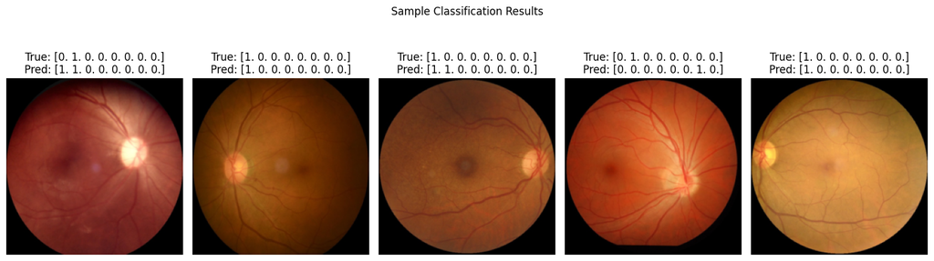

```python
# show some images example

# Show classification results
def show_classification_results(model, data_loader, num_samples=5):
    model.eval()  # Set the model to evaluation mode

    fig, axes = plt.subplots(1, num_samples, figsize=(15, 5))
    fig.suptitle("Sample Classification Results")

    samples_shown = 0

    # Iterate through the data loader
    with torch.no_grad():
        for images, labels in data_loader:
            # Ensure batch size and label dimensions are correct
            images, labels = images.to(device), labels.to(device)

            # Forward pass to get predictions
            outputs = model(images)
            predicted = (outputs > 0.3).float()  # Apply thresholding for classification

            # Loop through the batch to display the images
            for j in range(images.size(0)):
                if samples_shown >= num_samples:
                    break  # Stop after showing the desired number of samples

                # Get the current image and predictions
                img = images[j].permute(1, 2, 0).cpu().numpy()  # Convert tensor to numpy
                true_labels = labels[j].cpu().numpy()
                pred_labels = predicted[j].cpu().numpy()

                # Handle normalization (if applicable)
                img = (img - img.min()) / (img.max() - img.min())  # Rescale to [0, 1]

                # Display the image
                ax = axes[samples_shown]
                ax.imshow(img)
                ax.axis('off')

                # Display title with ground truth and predictions
                ax.set_title(f"True: {true_labels}\nPred: {pred_labels}")
                samples_shown += 1

            if samples_shown >= num_samples:
                break

    plt.tight_layout()
    plt.show()

# Example usage
show_classification_results(net, test_loader, num_samples=5)
```

Due to the heavy workload of training a model, the code snippet of the initial try-out model won't be placed. Instead, we will show the result that's obtained from the initial try-out.

For reference, the code of the try-out model is as below:

```
def createODIRNet(printtoggle=False):

    # Define the model class
    class ODIRNet(nn.Module):
        def __init__(self, printtoggle):
            super().__init__()

            ### Convolutional layers
            self.conv1 = nn.Conv2d(3, 16, kernel_size=3, stride=1, padding=1)
            # Input size: 224x224 -> After conv1 and maxpool: 112x112

            self.conv2 = nn.Conv2d(16, 32, kernel_size=3, stride=1, padding=1)
            # Input size: 112x112 -> After conv2 and maxpool: 56x56

            self.conv3 = nn.Conv2d(32, 64, kernel_size=3, stride=1, padding=1)
            # Input size: 56x56 -> After conv3 and maxpool: 28x28

            ### Fully connected layers
            self.fc1 = nn.Linear(64 * 28 * 28, 256)  # Flattened size is 64 * 28 * 28
            self.fc2 = nn.Linear(256, 128)
            self.out = nn.Linear(128, 8)  # Output layer for 8 classes (multi-label)

            # Toggle for printing tensor shapes
            self.print = printtoggle

        # Forward pass
        def forward(self, x):
            if self.print: print(f"Input: {x.shape}")

            # First convolutional block
            x = F.relu(F.max_pool2d(self.conv1(x), 2))
            if self.print: print(f"Layer conv1/pool1: {x.shape}")

            # Second convolutional block
            x = F.relu(F.max_pool2d(self.conv2(x), 2))
            if self.print: print(f"Layer conv2/pool2: {x.shape}")

            # Third convolutional block
            x = F.relu(F.max_pool2d(self.conv3(x), 2))
            if self.print: print(f"Layer conv3/pool3: {x.shape}")

            # Flatten the tensor for the fully connected layers
            nUnits = x.shape.numel() // x.shape[0]  # Total units per sample
            x = x.view(-1, nUnits)
            if self.print: print(f"Flattened: {x.shape}")

            # Fully connected layers
            x = F.relu(self.fc1(x))
            if self.print: print(f"Layer fc1: {x.shape}")

            x = F.relu(self.fc2(x))
            if self.print: print(f"Layer fc2: {x.shape}")

            x = torch.sigmoid(self.out(x))  # Use sigmoid for multi-label classification
            if self.print: print(f"Output layer: {x.shape}")

            return x

    # Create the model instance
    net = ODIRNet(printtoggle)

    # Loss function (Binary Cross Entropy for multi-label classification)
    lossfun = nn.BCELoss()

    # Optimizer
    optimizer = torch.optim.Adam(net.parameters(), lr=0.001)

    return net, lossfun, optimizer
```

The above figures are actually the enhanced results after obtaining the try-out figure below:

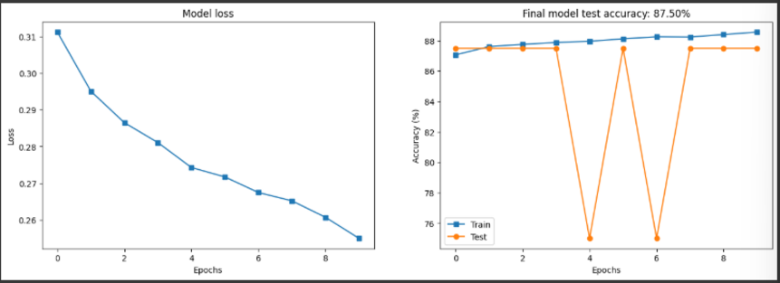

Based on the original try-out figures, the test accuracy fluctuates significantly, suggesting potential overfitting.

While after introducing **drop-out** method in the model, we could see from the obtained figures that:

- The training and test performance demonstrates a positive trend across the epochs, as evidenced by the loss and accuracy plots.
- The model's final test accuracy shows strong generalization, with minimal overfitting, as indicated by the small gap between the training and test accuracy curves. The test accuracy closely tracks the training accuracy, suggesting that the model is performing well on unseen data without overfitting to the training set.

For comparison, we will try to use one of the state-of-the-art CNN model and see its result.

Here we choose to use ResNet, specifically, **ResNet-18**, a light weight model compared to ResNet-50.

One thing that's worth noticing, since we converted our labels to **One-Hot Encoding**, which is **NOT** what ResNet expects.

So we need to merge them into one column for label classification instead.

We tried to run the model without applying any overfitting prevention, which causes us to received a result like this:

- Epoch 1/10, Loss: 1.3185, Train Accuracy: 51.50%, Test Accuracy: 54.81%
- Epoch 2/10, Loss: 1.0446, Train Accuracy: 60.53%, Test Accuracy: 49.80%
- Epoch 3/10, Loss: 0.8718, Train Accuracy: 67.04%, Test Accuracy: 54.26%
- Epoch 4/10, Loss: 0.6900, Train Accuracy: 75.14%, Test Accuracy: 59.66%
- Epoch 5/10, Loss: 0.4905, Train Accuracy: 83.14%, Test Accuracy: 59.97%
- Epoch 6/10, Loss: 0.3196, Train Accuracy: 90.34%, Test Accuracy: 59.03%
- ...

Therefore, we will introduce extra techniques like *Dropout*

We can see that **ResNet** is not outperforming at all.

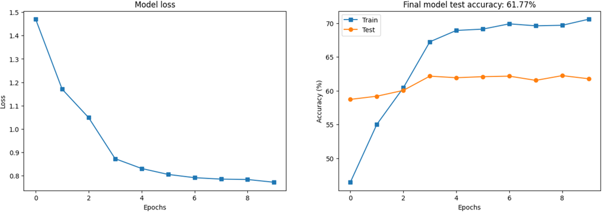

ResNet's pre-trained weights might not align well with the specific task, whereas CNN was built from scratch for it.

Now, we will try to do **transfer learning** on *ResNet* to see it's updated performance on the **ODIR** dataset.

```python
from torchvision import models
import torch.nn as nn
import torch.optim as optim


# Function for transfer learning and training ResNet
def trainResNet(model, train_loader, test_loader, num_epochs=10, learning_rate=0.001):
    device = torch.device("cuda" if torch.cuda.is_available() else "cpu")
    model.to(device)

    # Loss and optimizer with L2 regularization
    criterion = nn.BCEWithLogitsLoss()  # For multi-label classification
    optimizer = optim.SGD(model.parameters(), lr=learning_rate, momentum=0.9)

    train_loss = []
    train_acc = []
    test_acc = []

    # Training loop
    for epoch in range(num_epochs):
        model.train()
        epoch_loss = 0
        correct = 0
        total = 0

        for X, y in train_loader:
            X, y = X.to(device), y.to(device)

            optimizer.zero_grad()
            outputs = model(X)
            loss = criterion(outputs, y.float())
            loss.backward()
            optimizer.step()

            epoch_loss += loss.item() * X.size(0)

            # Calculate accuracy for multi-label classification
            predictions = torch.sigmoid(outputs) > 0.5  # Threshold for multi-label
            correct += (predictions == y).sum().item()
            total += y.numel()  # Total number of labels (not samples)

        train_loss.append(epoch_loss / total)
        train_acc.append(100 * correct / total)

        # Test the model
        model.eval()
        correct_test = 0
        total_test = 0
        test_loss = 0
        with torch.no_grad():
            for X_test, y_test in test_loader:
                X_test, y_test = X_test.to(device), y_test.to(device)

                outputs = model(X_test)
                loss = criterion(outputs, y_test.float())
                test_loss += loss.item() * X_test.size(0)

                # Calculate accuracy
                predictions = torch.sigmoid(outputs) > 0.5
                correct_test += (predictions == y_test).sum().item()
                total_test += y_test.numel()

        test_acc.append(100 * correct_test / total_test)
        # scheduler.step()  # Update the learning rate

        print(f"Epoch {epoch+1}/{num_epochs}, "
              f"Train Loss: {epoch_loss / total:.4f}, Train Accuracy: {100 * correct / total:.2f}%, "
              f"Test Loss: {test_loss / total_test:.4f}, Test Accuracy: {100 * correct_test / total_test:.2f}%")

    return train_loss, train_acc, test_acc
```

```python
# Initialize ResNet model
weights = models.ResNet18_Weights.DEFAULT
resnet = models.resnet18(weights=weights)
num_classes = 8  # Number of labels for multi-label classification

# Freeze all layers except the final layer
for param in resnet.parameters():
    param.requires_grad = False

# Replace the fully connected layer
resnet.fc = nn.Sequential(
    nn.Dropout(p=0.5),  # Dropout for regularization
    nn.Linear(resnet.fc.in_features, num_classes)  # Multi-label output
)

# Train the model with transfer learning
train_loss, train_acc, test_acc = trainResNet(resnet, train_loader,
                                              test_loader, num_epochs=10)
```

[output not shown]

```
Downloading: "https://download.pytorch.org/models/resnet18-f37072fd.pth" to /root/.cache/torch/hub/checkpoints/resnet18-f37072fd.pth
```

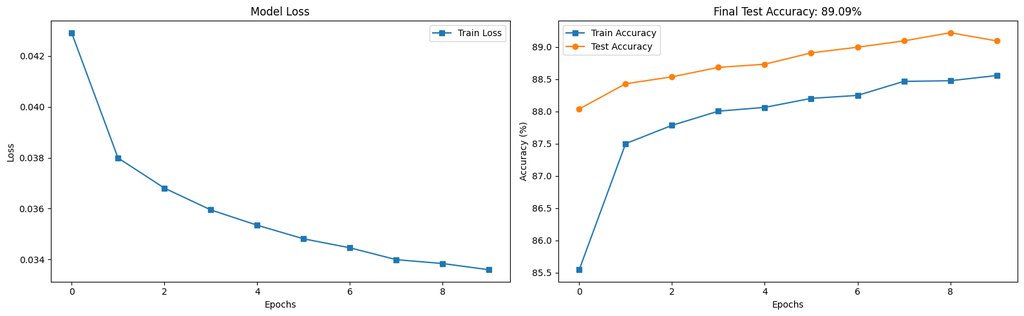

```python
# Loss Plot
fig, ax = plt.subplots(1, 2, figsize=(16, 5))

ax[0].plot(train_loss, 's-', label='Train Loss')
ax[0].set_xlabel('Epochs')
ax[0].set_ylabel('Loss')
ax[0].set_title('Model Loss')
ax[0].legend()

# Accuracy Plot
ax[1].plot(train_acc, 's-', label='Train Accuracy')
ax[1].plot(test_acc,'o-',label='Test Accuracy')
ax[1].set_xlabel('Epochs')
ax[1].set_ylabel('Accuracy (%)')
ax[1].set_title(f'Final Test Accuracy: {test_acc[-1]:.2f}%')
ax[1].legend()

plt.tight_layout()
plt.show()
```

As we can see, compared with the direct implementation of ResNet before transfer learning, we obtained a much better result.

For potentially obtaining a better result, we would like to try to use a deeper model ResNet101. However, due to the restriction of the computational resource, we won't perform it here at the moment.

By obtaining a better feature extraction model from CNN aspect, it'll potentially bring benefit for the GNN aspect later.

### 6. Methodology Exploration

Instead of approaching the image analysis by using traditional CNN model for independent processing, an idea of incorporating inter-image relationships that could reveal additional insight is brought up.

Diseases often share features across patients, and relationships like similarity between images (E.g. based on feature vectors) could improve classification.

The hybrid CNN-GNN model that's proposed here is particularly relevant to this approach as it:

- Enhances classification by leveraging relational reasoning between images.
- Combines local feature learning (CNN) with global structural learning (GNN).
- Addresses scenarios where labeled data is limited by transferring knowledge through graph edges.

##### What is GNN

Graph Neural Networks are deep learning architectures designed to operate on graph-structured data. A graph consists of:

- Nodes:

  represent entities (E.g. fundus images in this case).
- Edges:

  represent relationships between nodes (E.g. feature similarity).

How GNNs work:

- Message passing:

  nodes aggregate feature information from their neighbors using edges as pathways.
- Graph Convolutions:

  Like CNNs for images, GNNs apply convolution-like operations to update node features based on neighbors.
- Pooling:

  Node features are combined for graph-level tasks or remian separate for node-level predictions.

CNN vs. GNN

- CNN:

  Extracts spatial features from grid-structured data like images.
- GNN:

  Models irregular data structures and relationships like graphs.

##### Build the GNN model

Under this scenario, where we only have images and lebels, we construct a graph where:

- Node: images
- Node features: Extracted by CNN
- Edges: similarity between images (based on cosine similarity of CNN feature vectors)

Steps to build the GNN:

- Node features: Pass images through a pre-trained CNN to extract feature vectors for each image.
- Graph construction: Define edges based on a similarity threshold or KNN in the feature space.

  Create an adjacency matrix or edge list.
- GNN layers: Use GraphSAGE, GCNConv, or GAT for graph convolutions.

  Output final node-level predictions.

##### Model Construction

Firstly, we will bring up the customized CNN again for feature extraction.

Then, we will bring up the GNN for relational learning.

After that, we will combine CNN and GNN.

Here we will implement a simple processing.

```python
# For feature extraction, we should remove two parts:
# Fully connected layers and output layers, since they're task-specific

def createODIRFeatureExtractor(printtoggle=False):
    # Define the feature extractor class
    class ODIRFeatureExtractor(nn.Module):
        def __init__(self, printtoggle):
            super().__init__()

            ### Convolutional layers
            self.conv1 = nn.Conv2d(3, 16, kernel_size=3, stride=1, padding=1)
            self.conv2 = nn.Conv2d(16, 32, kernel_size=3, stride=1, padding=1)
            self.conv3 = nn.Conv2d(32, 64, kernel_size=3, stride=1, padding=1)
            self.conv4 = nn.Conv2d(64, 128, kernel_size=3, stride=1, padding=1)

            # Toggle for printing tensor shapes
            self.print = printtoggle

        # Forward pass
        def forward(self, x):
            if self.print: print(f"Input: {x.shape}")

            # Convolutional layer
            x = F.relu(F.max_pool2d(self.conv1(x), 2))

            x = F.relu(F.max_pool2d(self.conv2(x), 2))

            x = F.relu(F.max_pool2d(self.conv3(x), 2))

            x = F.relu(F.max_pool2d(self.conv4(x), 2))

            # Flatten the tensor for feature extraction
            nUnits = x.shape.numel() // x.shape[0]  # Total units per sample
            x = x.view(-1, nUnits)

            return x  # Output feature vector

    # Create the feature extractor instance
    feature_extractor = ODIRFeatureExtractor(printtoggle)

    # Optimizer (optional, if the feature extractor needs training or fine-tuning)
    optimizer = torch.optim.Adam(feature_extractor.parameters(), lr=0.001)

    return feature_extractor, optimizer
```

```python
!pip install torch_geometric
from torch_geometric.data import Data
from torch_geometric.utils import dense_to_sparse
```

```
     ━━━━━━━━━━━━━━━━━━━━━━━━━━━━━━━━━━━━━━━━ 63.1/63.1 kB 6.1 MB/s eta 0:00:00
Downloading torch_geometric-2.6.1-py3-none-any.whl (1.1 MB)
   ━━━━━━━━━━━━━━━━━━━━━━━━━━━━━━━━━━━━━━━━ 1.1/1.1 MB 28.6 MB/s eta 0:00:00
```

```python
# Extract features from CNN
feature_extractor, _ = createODIRFeatureExtractor()
feature_extractor.eval()  # Set to evaluation mode

# Function to extract features
def extract_features(loader, feature_extractor):
    features_list, labels_list = [], []

    with torch.no_grad():
        for images, labels in loader:
            features = feature_extractor(images)  # Extract features
            features_list.append(features)
            labels_list.append(labels)

    # Concatenate all features and labels
    features = torch.cat(features_list, dim=0)
    labels = torch.cat(labels_list, dim=0)

    return features, labels

# Extract features for training and testing data
train_features, train_labels = extract_features(train_loader, feature_extractor)
test_features, test_labels = extract_features(test_loader, feature_extractor)
```

Computing the cosine similarity matrix for all pairs of features, which creates a dense N*N matrix that becomes infeasible for large N (number of samples), which makes System RAM running out.

Therefore, we introduce KNN, K Nearest Neighbor, to limit the number of edges and avoid memory overhead.

This approach computes similarities only for the nearest neighbors of each node, making it sparse and efficient.

```python
# Construct the graph using train_features (as node features)
# Define edges based on similarity

# Define edges using cosine similarity
from sklearn.neighbors import NearestNeighbors
from torch_geometric.utils import from_scipy_sparse_matrix
import scipy.sparse as sp

def define_graph(features, labels, k=10):
    # Use k-NN to find nearest neighbors
    knn = NearestNeighbors(n_neighbors=k, metric="cosine")
    knn.fit(features.cpu().numpy())  # Convert to NumPy for k-NN computation
    distances, indices = knn.kneighbors(features.cpu().numpy())

    # Build sparse adjacency matrix
    row_indices = []
    col_indices = []
    for i, neighbors in enumerate(indices):
        for neighbor in neighbors:
            row_indices.append(i)
            col_indices.append(neighbor)
    adjacency_matrix = sp.coo_matrix(
        (np.ones_like(row_indices), (row_indices, col_indices)),
        shape=(features.shape[0], features.shape[0]),
    )

    # Convert sparse matrix to edge index format
    edge_index, _ = from_scipy_sparse_matrix(adjacency_matrix)

    # Create the graph data object
    return Data(x=features, edge_index=edge_index, y=labels)

# Create graph data
train_graph = define_graph(train_features, train_labels, k=9)
test_graph = define_graph(test_features, test_labels, k=9)
```

```python
# define a model, like a simple Graph Convolutional Network

from torch_geometric.nn import GCNConv

class SimpleGNN(nn.Module):
    def __init__(self, in_channels, hidden_channels, out_channels):
        super().__init__()
        self.conv1 = GCNConv(in_channels, hidden_channels)
        self.conv2 = GCNConv(hidden_channels, out_channels)

    def forward(self, x, edge_index):
        x = self.conv1(x, edge_index)
        x = torch.relu(x)
        x = self.conv2(x, edge_index)
        return torch.sigmoid(x)  # Multi-label output
```

```python
# initialize the model
gnn = SimpleGNN(
    in_channels=train_graph.x.shape[1],  # Number of input features
    hidden_channels=256,  # Size of hidden layer
    out_channels=train_graph.y.shape[1]  # Number of output classes
)
```

```python
criterion = nn.BCELoss()  # Binary Cross-Entropy Loss
optimizer = torch.optim.Adam(gnn.parameters(), lr=0.001)

num_epochs = 20
losses = []
train_acc = []
test_acc = []

for epoch in range(num_epochs):
    gnn.train()
    optimizer.zero_grad()

    # Forward pass
    outputs = gnn(train_graph.x, train_graph.edge_index)
    loss = criterion(outputs, train_graph.y)
    losses.append(loss.item())

    # Backward pass and optimization
    loss.backward()
    optimizer.step()

    # Calculate training accuracy
    predicted_train = (outputs > 0.5).float()
    correct_train = (predicted_train == train_graph.y).float().mean()
    train_acc.append(correct_train.item())

    # Evaluation on test set
    gnn.eval()
    with torch.no_grad():
        test_outputs = gnn(test_graph.x, test_graph.edge_index)
        test_loss = criterion(test_outputs, test_graph.y)

        # Test accuracy
        predicted_test = (test_outputs > 0.5).float()
        correct_test = (predicted_test == test_graph.y).float().mean()
        test_acc.append(correct_test.item())

    print(f"Epoch {epoch+1}/{num_epochs}, Loss: {loss.item():.4f}, Train Accuracy: {correct_train.item():.4f}")
    print(f"Test Loss: {test_loss.item():.4f}, Test Accuracy: {correct_test.item():.4f}")
```

[output not shown]

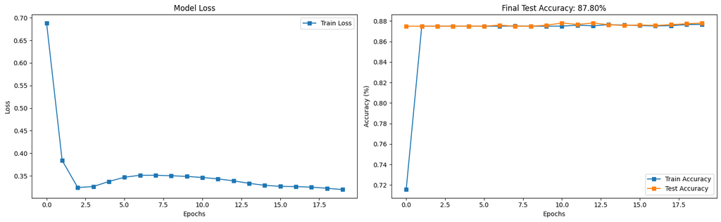

```python
# Loss Plot
fig, ax = plt.subplots(1, 2, figsize=(16, 5))

ax[0].plot(losses, 's-', label='Train Loss')
ax[0].set_xlabel('Epochs')
ax[0].set_ylabel('Loss')
ax[0].set_title('Model Loss')
ax[0].legend()

# Accuracy Plot
ax[1].plot(train_acc, 's-', label='Train Accuracy')
ax[1].plot(test_acc, 's-', label = 'Test Accuracy')
# Highlight final accuracy
# ax[1].plot([train_acc[-1]] * num_epochs, 'k--', label='Final Train Accuracy')
# Highlight final test accuracy
# ax[1].plot([test_acc[-1]] * num_epochs, 'r--', label='Final Test Accuracy')
ax[1].set_xlabel('Epochs')
ax[1].set_ylabel('Accuracy (%)')
ax[1].set_title(f'Final Test Accuracy: {test_acc[-1]*100:.2f}%')
ax[1].legend()

plt.tight_layout()
plt.show()
```

The training accuracy fluctuates slightly but improves overall, while the test accuracy stabilizes at approximately 87.8%. This consistency between training and test performance implies that the model is not significantly overfitting.

### 7. Challenges and Next steps

The results above demonstrate a promising baseline for GNN-based approach, with good generalization indicated by the similar test and train accuracies.

And here we bring up the challenges we are facing:

- Hybrid GNN-CNN Setup:

  If the GNN is using features extracted from a pre-trained CNN, this indirectly makes the approach hybrid. While effective, it might limit the ability to fully exploit the graph structure for richer relational learning.

  Dependence on the CNN for feature extraction might lead to suboptimal performance if the CNN features are not adequately expressive.
- Model Scalability:

  GNNs often struggle with large graphs due to computational constraints, particularly in the context of multi-label classification tasks.
- Limited Accuracy Gains:

  Although the results are decent, the accuracy plateau suggests potential limitations in either the feature representation or the GNN architecture itself.

Based on these challenges, we will take the next steps as below:

- Direct End-to-End Hybrid CNN-GNN:

  Instead of relying on pre-trained CNN features, explore end-to-end architectures where the CNN acts as the initial feature extractor, feeding into the GNN in a unified pipeline. This may allow better optimization of both components.
- Graph Construction Improvements:
  - Refine the way the graph is constructed:
    - Consider incorporating domain-specific knowledge to define edge relationships.
    - Experiment with dynamic graphs where the edge connections evolve based on the learning process.
  - Model Optimization:
    - Experiment with advanced GNN architectures such as Graph Attention Networks (GATs) or Graph Isomorphism Networks (GINs) for potentially better performance.
    - Hyperparameter tuning, including learning rate schedules, weight initialization strategies, and dropout rates, may yield further gains
  - Data Augmentation for Graphs:
    - Investigate graph data augmentation techniques to increase the diversity of graph structures and improve the model's robustness.
  - Transfer Learning for GNNs:
    - Pre-train the GNN on a larger, related dataset (if available) and fine-tune it on your task. This could improve accuracy by leveraging learned graph representations.

For meeting the need of transfer learning and more data, we have **RFMiD** dataset that can be used. However, extra feature engineering and EDA are required to reform the dataset to the ideal and matching format.